# hCBO merge data

Qiang (Danny) Chen

2025-09-19

We integrated *GM25256, NCRM5, GM23913* at day60 in our 2 month-old hCBO data with the following two datasets and identified DEGs among cerebellar markers across protocols.

For the quadrato lab, we focused on three samples below (they generated three replicates at day 60):  
GSE247974 GSM7904010: organoid D1, scRNA-seq  
GSM7904011: organoid D2, scRNA-seq  
GSM7904012: organoid D3, scRNA-seq

For the pasca lab, we only focused on one sample (at day 72) below:  
GSE233574 GSM7430706: OrganoidScreen; sample11; FGF2-50

```r
# knitr::opts_chunk$set(tidy=FALSE, cache=FALSE, echo=TRUE, dev="png", message=FALSE, error=FALSE, warning=FALSE)
knitr::opts_chunk$set(echo=TRUE, warning=F, message=F)

library("tidyr")
library("dplyr")
library("ggplot2")
library("knitr")
library("pheatmap")
library("DT")

library("Seurat")
library("DESeq2")

rm(list=ls())

d_geo  = "/data/qiangchen/Projects/NCATS/SCTL/SeungMiRyu/hCBO/GEO/"
d_sctl = "/data/qiangchen/Projects/NCATS/SCTL/SeungMiRyu/hCBO/ISB038/htseq_count/"

d_proj = "/data/qiangchen/Projects/NCATS/SCTL/SeungMiRyu/hCBO/SCTLday60_GSE247974_GSE233574/"
d_dat  = paste0(d_proj, "Data/")
d_res  = paste0(d_proj, "Results/")
```

# 1 Load SCTL data

```r
f_sctl = paste0(d_sctl, "ISB038.counts.Rdata")
load(f_sctl)

countData_SCTL = as.data.frame(df)

colnames = colnames(countData_SCTL)
colnames = gsub("_htseq_counts", "", colnames)
colnames = gsub("-", "_", colnames)
colnames(countData_SCTL) = colnames

cols_selected = c(1, grep("day60", colnames))

countData_SCTL = countData_SCTL[, cols_selected]

countTable_SCTL = countData_SCTL[, 2:ncol(countData_SCTL)]
print(nrow(countData_SCTL))
```

[output not shown]

# 2 Load GSE247974 data

```r
samples = c("GSM7904010_D1", "GSM7904011_D2", "GSM7904012_D3")

bulkList = lapply(samples, function(cur_sample) {

    d_sample = paste0(d_geo, "GSE247974/Raw/", cur_sample, "/")
    cur_data = Read10X(data.dir = d_sample)
    cur_so  = CreateSeuratObject(counts=cur_data, project=cur_sample)

    cur_metadata = cur_so@meta.data
    cur_group = as.numeric(as.factor(cur_metadata$orig.ident))

    count_matrix = GetAssayData(cur_so, assay = "RNA", slot = "counts")

    pseudobulk = data.frame(t(rowsum(t(as.matrix(count_matrix)), group=cur_group)))
    colnames(pseudobulk) = cur_sample

    return(pseudobulk)

})

countTable_GSE247974 = as.data.frame(do.call(cbind, bulkList))
colnames(countTable_GSE247974) = c("GSE247974_day60_1", "GSE247974_day60_2", "GSE247974_day60_3")
countData_GSE247974 = cbind(Gene=rownames(countTable_GSE247974), countTable_GSE247974)

print(nrow(countData_GSE247974))
```

[output not shown]

# 3 Load GSE233574 data

We used only sample11 in this study. Sample11 includes 29910 features and 1028 cells. To conduct DEG analysis, we generated 3 bulk-RNA data using subsmples of cells. Each subsample includes randomly selected 80% of total cells.

```r
f_GSE233574 = paste0(d_geo, "GSE233574/Raw/GSE233574_OrganoidScreen_processed_SeuratObject.rds")

so_GSE233574 = readRDS(f_GSE233574)

so_GSE233574 = subset(so_GSE233574, subset=sample=="sample11")
metadata_GSE233574 = so_GSE233574@meta.data

count_matrix = GetAssayData(so_GSE233574, assay = "RNA", slot = "counts")

n_total = ncol(count_matrix)

# Calculate 80% of indices
n_cells = floor(0.8 * n_total)

group = 1:n_cells

# Generate random subsample of indices
subsample_ind1 = sample(1:n_total, size = n_cells, replace = FALSE)
subsample_ind2 = sample(1:n_total, size = n_cells, replace = FALSE)
subsample_ind3 = sample(1:n_total, size = n_cells, replace = FALSE)

count1 = rowSums(count_matrix[, subsample_ind1])
count2 = rowSums(count_matrix[, subsample_ind2])
count3 = rowSums(count_matrix[, subsample_ind3])

countData_GSE233574 = data.frame(Sub1=count1, Sub2=count2, Sub3=count3)
countData_GSE233574 = cbind(rownames(countData_GSE233574), countData_GSE233574)
colnames(countData_GSE233574) = c("Gene", "GSE233574_day72_1", "GSE233574_day72_2", "GSE233574_day72_3")

print(nrow(countData_GSE233574))
```

[output not shown]

# 4 Merge counts

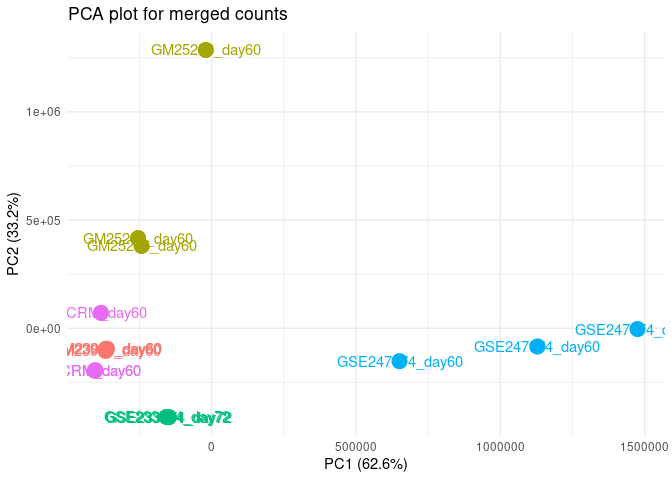

```r
merged = merge(countData_SCTL, countData_GSE247974, by="Gene")
print(nrow(merged))

merged = merge(merged, countData_GSE233574, by="Gene")
print(nrow(merged))

count_matrix = merged[, 2:ncol(merged)]
rownames(count_matrix) = merged$Gene

f_counts = paste0(d_dat, "raw_counts.SCTL_GSE247974_GSE233574.tsv")
write.table(count_matrix, f_counts, sep="\t", row.names=F, quote=F)

pca_result = prcomp(t(count_matrix))
pca_scores = as.data.frame(pca_result$x)
pca_scores$Sample = rownames(pca_scores)
pca_scores$Group = pca_scores$Sample
pca_scores$Group = gsub("_1", "", pca_scores$Group)
pca_scores$Group = gsub("_2", "", pca_scores$Group)
pca_scores$Group = gsub("_3", "", pca_scores$Group)
pca_scores$Group = as.factor(pca_scores$Group)

p = ggplot(pca_scores, aes(x = PC1, y = PC2, color = Group, label=Group)) +
    geom_point(size = 5) +
    geom_text() +
    theme_minimal() +
    labs(title = "PCA plot for merged counts",
       x = paste0("PC1 (", round(summary(pca_result)$importance[2, 1] * 100, 1), "%)"),
       y = paste0("PC2 (", round(summary(pca_result)$importance[2, 2] * 100, 1), "%)")) +
    theme(legend.position = "none")

print(p)
```

[output not shown]

```r
f_fig = paste0(d_res, "PCA_plot.merged.D60_D72.before_normalization.pdf")
ggsave(f_fig, p)
```

# 5 Boxplot of raw counts.

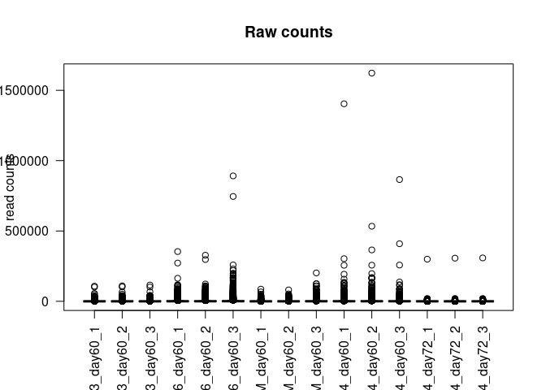

```r
boxplot(count_matrix,main="Raw counts", ylab = "read counts", las=2)
```

# 6 QC

QC was done following the same approach in previous analysis for this project

```r
sampleInfo = data.frame(ID = colnames(count_matrix))
sampleInfo = sampleInfo %>% separate(ID, into=c("Sample", "Day", "Replicate"), remove=F)
sampleInfo$Protocol = "SCTLday60"
sampleInfo$Protocol[sampleInfo$Sample=="GSE247974"] = "GSE247974"
sampleInfo$Protocol[sampleInfo$Sample=="GSE233574"] = "GSE233574"

sampleInfo$Protocol = factor(sampleInfo$Protocol, levels=c("SCTLday60", "GSE247974", "GSE233574"))

table(sampleInfo$Protocol, sampleInfo$Sample)
```

```
##
##             GM23913 GM25256 GSE233574 GSE247974 NCRM
##   SCTLday60       3       3         0         0    3
##   GSE247974       0       0         0         3    0
##   GSE233574       0       0         3         0    0
```

```r
f_sample = paste0(d_dat, "sample_info.SCTLday60_GSE247974_GSE233574.tsv")
write.table(sampleInfo, f_sample, sep="\t", row.names=F, quote=F)

q = which(rowSums(count_matrix) > 10)
count_matrix = count_matrix[q, sampleInfo$ID]

f_count = paste0(d_dat, "count_matrix.SCTLday60_GSE247974_GSE233574.qced.rda")
save(count_matrix, sampleInfo, file=f_count)
```

```r
rm(list=ls())
```